### Results

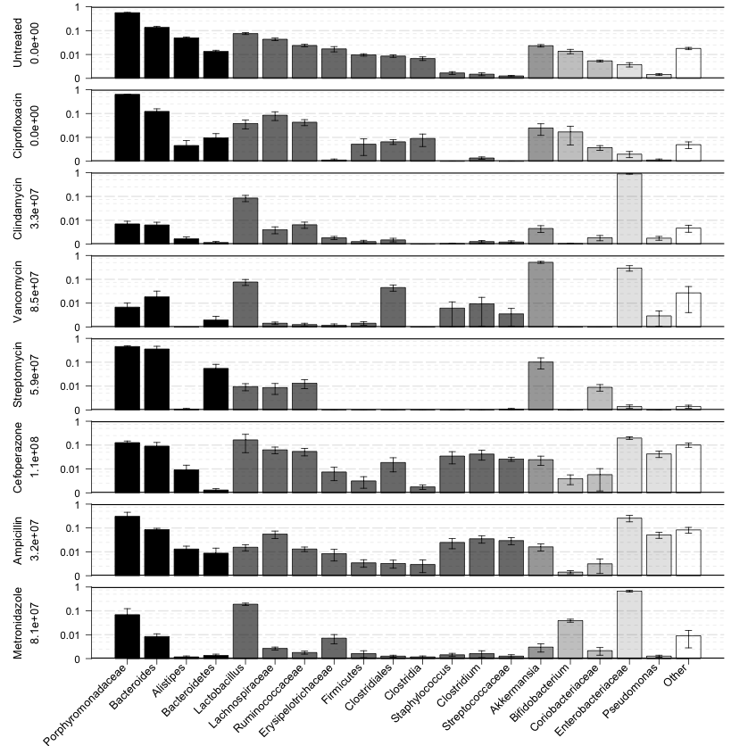

[figure not shown]

**Supplemental Figure 1. Diversity is nevatively correlated with *C. difficile* levels.** This figure shows the relationship between the inverse simpson diversity index of microbiotas of each experimental group on day 0 and *C. difficile* CFU/g feces on day 1. Spearman’s rho is plotted in the top right corner.

### CFU stats comparison

> To compare CFU levels:

```r
file<-read.csv("~/Documents/Github/abxD01/Figure1/abxD01.final.tx.1.subsample.relabund.topdose2.forlogscale.csv", header=T)

data <- file[ which(file$expgroup != '1untr'), ] #choose experimental groups
data$nextDayCFU<-log10(data$nextDayCFU+1) #log transform CFUs
anova(lm(data$nextDayCFU ~ data$expgroup)) #perform anova across experimental groups for CFU
```

```
## Analysis of Variance Table
##
## Response: data$nextDayCFU
##               Df  Sum Sq Mean Sq F value  Pr(>F)
## data$expgroup  6 257.981  42.997   23.73 6.9e-12 ***
## Residuals     41  74.289   1.812
## ---
## Signif. codes:  0 '***' 0.001 '**' 0.01 '*' 0.05 '.' 0.1 ' ' 1
```

```r
#Which groups are different? Ciprofloxacin was clearly lower
data <- data[ which(data$expgroup != '2cipro'), ] #remove ciprofloxacin to see now if there's a difference in remaining groups
anova(lm(data$nextDayCFU ~ data$expgroup))
```

```
## Analysis of Variance Table
##
## Response: data$nextDayCFU
##               Df Sum Sq Mean Sq F value Pr(>F)
## data$expgroup  5 21.018  4.2036  2.0936 0.0881 .
## Residuals     37 74.289  2.0078
## ---
## Signif. codes:  0 '***' 0.001 '**' 0.01 '*' 0.05 '.' 0.1 ' ' 1
```

### Amova to compare resulting community structures

> Amova calculation in mothur to determine the uniqueness of each community structure:

```
dist.shared(shared=abxD01.final.an.unique_list.0.03.topdose2.shared, calc=thetayc-jclass, subsample=1625)
amova(phylip=abxD01.final.an.unique_list.0.03.topdose2.thetayc.0.03.lt.ave.dist, design=topdose_design_byABX.txt, iters=1000000)
```

> This results in the file called “abxD01.final.an.unique_list.0.03.topdose2.thetayc.0.03.lt.ave.amova” located in the github folder. The results of these are summarized in “amova8expgroups.xlsx”.